# Difference-in-Differences

The 2×2, staggered adoption, synthetic DiD, and common pitfalls

Daniel Winkler

2026-09-30

## Roadmap

| Case | What it teaches |
| --- | --- |
| 01 | The 2×2, TWFE, event study, placebo, Callaway–Sant’Anna, synthetic DiD |
| 02 | Parallel trends within covariate groups; weighting |
| 03 | Selection on a temporary dip before adoption |
| 04–05 | Staggered adoption and the Goodman-Bacon decomposition |
| 06 | Spillovers to control stores |
| 07 | Effects that differ by an observed store characteristic |
| 08 | Controlling for a mediator (optional) |

# Case 01: the 2×2 benchmark

## Case 01: loyalty offer in half the stores

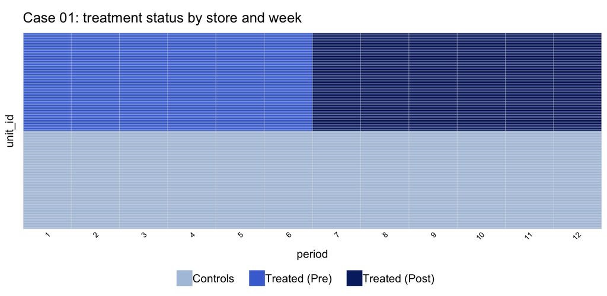

## Look at the group means first

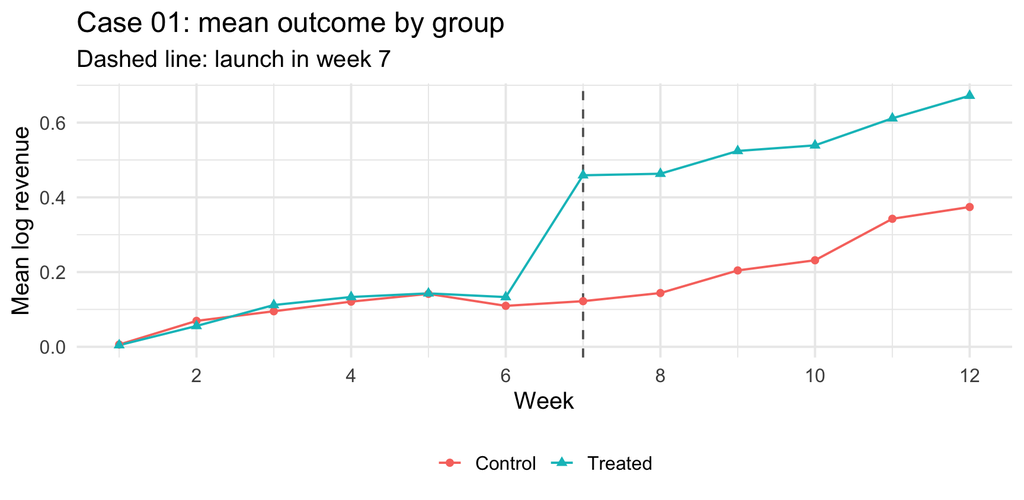

## What DiD estimates

Potential outcomes $Y_{it}(1)$ and $Y_{it}(0)$; treatment starts in week $g$.

$$\text{ATT} = \mathbb{E}\big[\,Y_{it}(1) - Y_{it}(0) \mid \text{treated},\ t \ge g\,\big]$$

For treated stores after launch, $Y_{it}(0)$ is never observed. DiD fills it in with the control group’s change over the same weeks.

In every case the outcome is log weekly revenue and standard errors are clustered by unit. Tables show the planted ATT, the true effect in the simulation.

## What DiD assumes

1. **Parallel trends**: without treatment, treated and control units would have changed by the same amount on average.
2. **No anticipation**: before week $g$, treated units’ outcomes equal $Y(0)$.
3. **SUTVA** (stable unit treatment value assumption), here no interference: a control unit’s outcome does not depend on who is treated.

Parallel trends concerns changes over time; fixed effects absorb time-invariant (constant) differences.

## The 2×2 by hand

| Group | Pre | Post | Change |
| --- | --- | --- | --- |
| Treated | 0.097 | 0.545 | 0.448 |
| Control | 0.090 | 0.236 | 0.146 |

$$\begin{aligned}
\widehat{\text{DiD}} &= (\bar y_{T,\text{post}} - \bar y_{T,\text{pre}}) - (\bar y_{C,\text{post}} - \bar y_{C,\text{pre}}) \\
&= (0.545 - 0.097) - (0.236 - 0.090) \\
&= 0.448 - 0.146 \\
&= 0.302
\end{aligned}$$

## The same number from a regression

$$y_{it} = \alpha_i + \lambda_t + \beta\, D_{it} + \varepsilon_{it}$$

$D_{it} = \text{Treated}_i \times \text{Post}_t$ is `treated`: 1 only for treated-group stores in weeks 7–12. It is not `ever_treated`, which $\alpha_i$ absorbs.

```r
twfe_fit_01 <- feols(outcome ~ treated | unit_id + period,
                     vcov = ~unit_id, data = d01)
```

Two-way fixed effects (TWFE): $\hat\beta =$ 0.3020 (SE 0.0120). The 2×2 by hand: 0.3020.

With one adoption date and a balanced panel, TWFE *is* the 2×2.

## Event study: inspect the pre-period

$$y_{it} = \alpha_i + \lambda_t + \textstyle\sum_{k \ne 6} \beta_k\, \mathbf{1}\{t = k\}\cdot \text{Treated}_i + \varepsilon_{it}$$

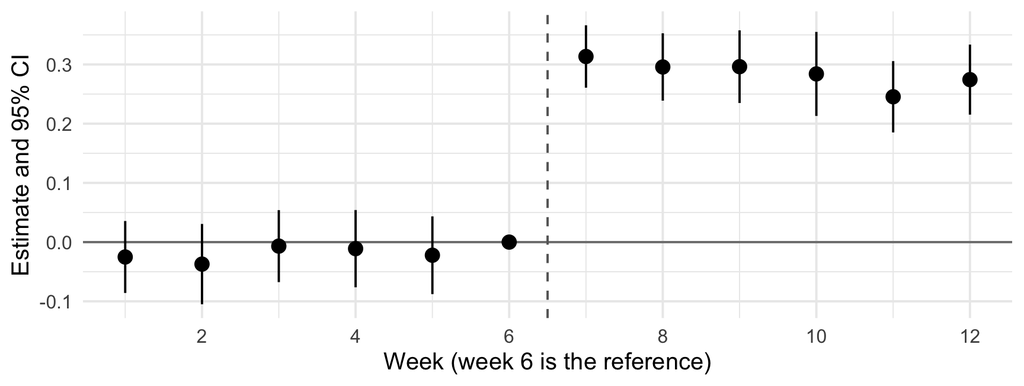

Joint Wald test that weeks 1–5 are zero: p = 0.855.

## Placebo: pretend treatment started earlier

```r
placebo_fit_01 <- feols(
  outcome ~ placebo_treated | unit_id + period,
  vcov = ~unit_id,
  data = d01 |>
    filter(period < g01) |>
    mutate(
      placebo_treated = as.integer(ever_treated == 1 & period >= g01 - 3L)
    )
)
```

A fake week-4 launch, using pre-launch weeks only: 0.012 (SE 0.017).

The placebo and the event-study leads use the same pre-period comparison. Neither tests parallel trends after launch.

## Two alternatives to TWFE

**Callaway–Sant’Anna**: estimate $\text{ATT}(g,t)$ for each cohort $g$ and week $t$ from one clean 2×2 against never-treated units, measured from week $g-1$. Then average the $\text{ATT}(g,t)$ with weights you choose.

**Synthetic DiD** (Arkhangelsky et al. 2021): reweight control units so their pre-launch path parallels the treated path, and reweight pre-launch weeks to resemble the post-launch weeks. Then run DiD on the weighted panel.

$$\hat\tau = \arg\min_{\tau,\mu,\alpha,\beta} \textstyle\sum_{i,t} \big(y_{it} - \mu - \alpha_i - \beta_t - D_{it}\,\tau\big)^2\ \hat\omega_i\,\hat\lambda_t$$

## Case 01: the estimators agree

| Specification | Estimate | Std. error | Planted ATT |
| --- | --- | --- | --- |
| TWFE | 0.302 | 0.012 | 0.3 |
| Callaway–Sant’Anna | 0.285 | 0.024 | 0.3 |
| Synthetic DiD | 0.299 | 0.012 | 0.3 |

In a clean design the alternatives add little. Each later case changes one thing about this design.

## Case 01: synthetic DiD’s fit

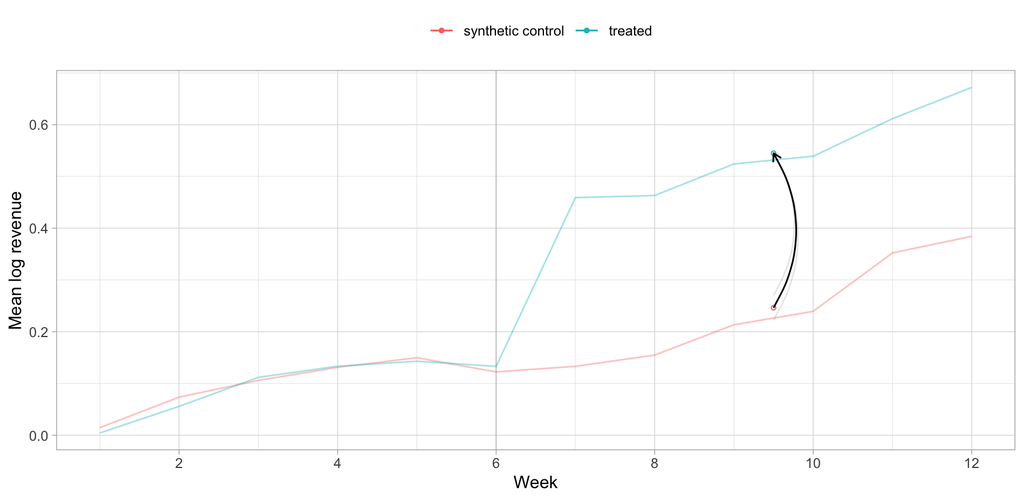

# Case 02: parallel trends within groups

## Case 02: CRM adoption varies with growth segment

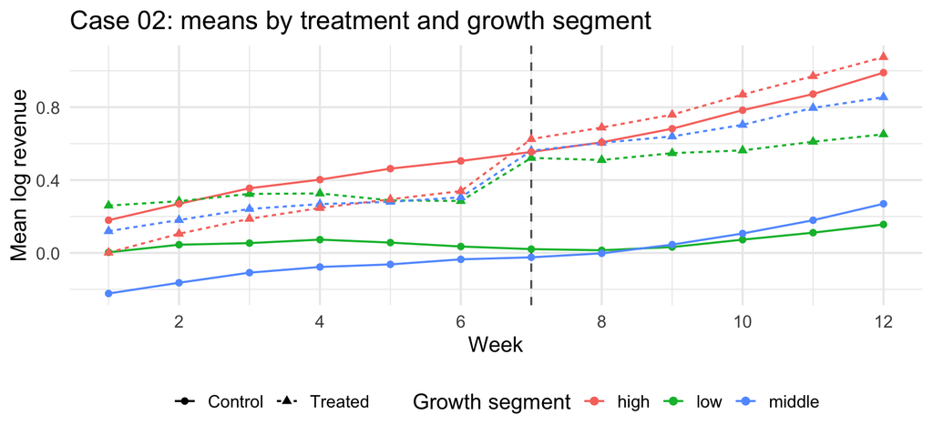

High-growth retailers adopt more often and grow faster anyway.

## Case 02: adjust for the segment

| Specification | Estimate | Std. error | Planted ATT |
| --- | --- | --- | --- |
| TWFE, no adjustment | 0.372 | 0.025 | 0.25 |
| TWFE weighted by inverse propensity (segment) | 0.251 | 0.028 | 0.25 |
| Callaway–Sant’Anna IPW (segment) | 0.251 | 0.007 | 0.25 |
| Synthetic DiD (no covariates) | 0.283 | 0.017 | 0.25 |

Inverse-propensity weighting (IPW) reweights controls to the treated segment mix. It assumes trends are parallel within segments and that every segment has both treated and control retailers.

## Case 02: check what the weights do

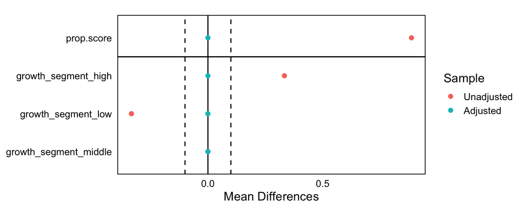

## Case 02: synthetic DiD’s fit

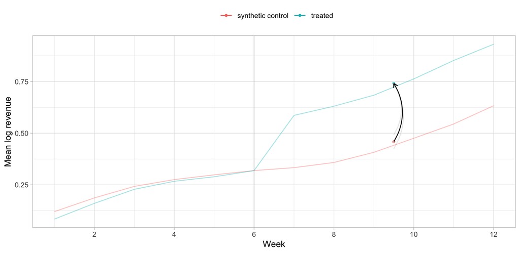

## Case 02: where synthetic DiD puts its weight

| Segment | Unweighted control share | Synthetic DiD weight | Treated share |
| --- | --- | --- | --- |
| high | 0.167 | 0.324 | 0.500 |
| low | 0.500 | 0.255 | 0.167 |
| middle | 0.333 | 0.420 | 0.333 |

Synthetic DiD never sees the segment. Matching pre-launch paths moves weight toward high-growth controls. Estimate 0.283 against unadjusted TWFE 0.372.

# Case 03: selection before adoption

## Case 03: stores adopt after a sales slump

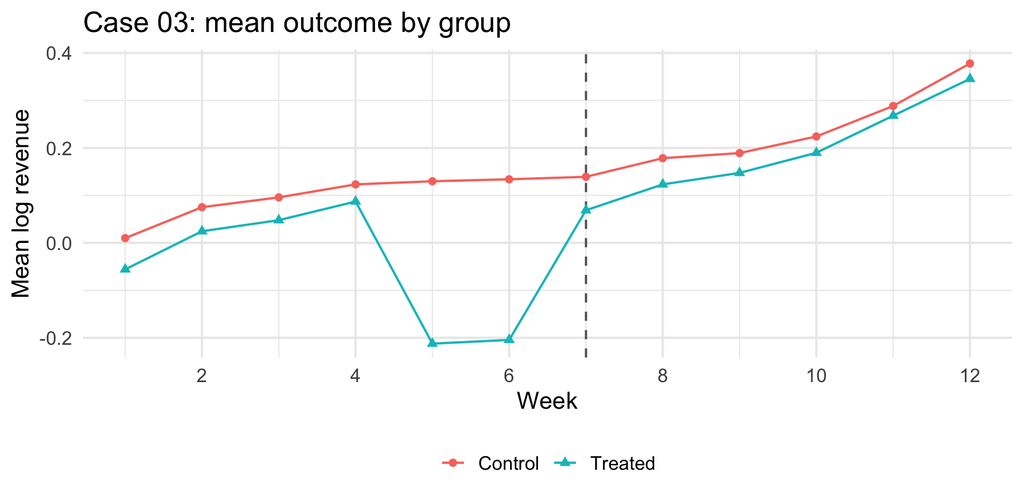

## Case 03: the dip shows in the event study

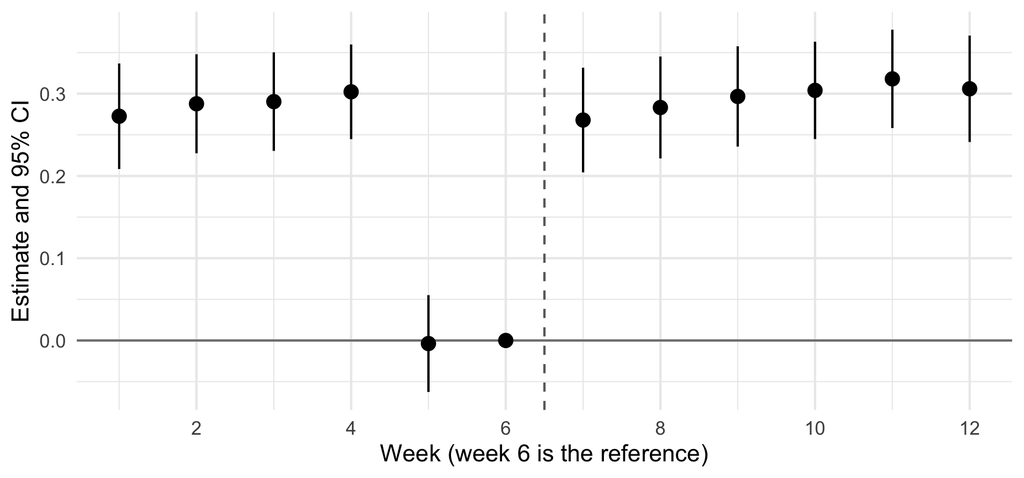

Pre-test p = 0.000: adopting stores dip in weeks 5–6, then recover.

## Case 03: which baseline?

| Specification | Estimate | Std. error | Planted ATT |
| --- | --- | --- | --- |
| TWFE | 0.104 | 0.012 | 0 |
| Synthetic DiD | 0.085 | 0.012 | 0 |
| Callaway–Sant’Anna, base week 6 | 0.296 | 0.024 | 0 |
| Callaway–Sant’Anna, anticipation = 2 (base week 4) | -0.006 | 0.020 | 0 |

- TWFE and synthetic DiD average the dip into the baseline; the default Callaway–Sant’Anna baseline, week 6, is the bottom of the dip.
- `anticipation = 2` moves the baseline to week 4. This assumes the slump would have reversed without the software, which the data cannot show.

# Cases 04–05: staggered adoption

## Cases 04 and 05: three cohorts plus never-treated

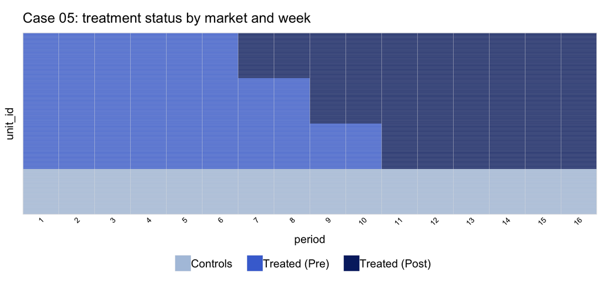

Both cases share the same adoption timing. The effect is constant in Case 04 and grows with exposure in Case 05.

## Cohort means

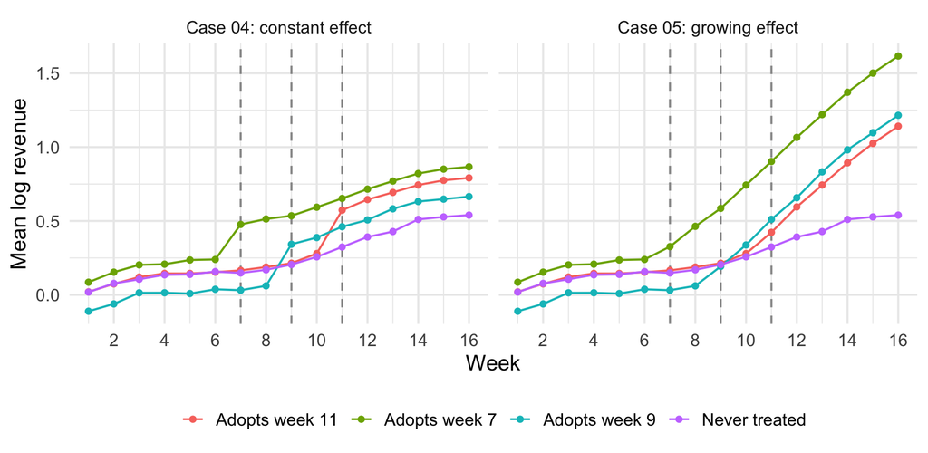

## TWFE breaks only when effects change over time

| Case | Estimator | Estimate | Std. error | Planted ATT |
| --- | --- | --- | --- | --- |
| 04 | TWFE | 0.245 | 0.004 | 0.250 |
| 04 | Callaway–Sant’Anna | 0.239 | 0.007 | 0.250 |
| 04 | Sun–Abraham | 0.239 | 0.007 | 0.250 |
| 05 | TWFE | 0.301 | 0.018 | 0.467 |
| 05 | Callaway–Sant’Anna | 0.456 | 0.011 | 0.467 |
| 05 | Sun–Abraham | 0.456 | 0.007 | 0.467 |

Parallel trends holds in both cases. The TWFE gap in Case 05 comes from the estimator.

## Goodman-Bacon (2021): TWFE averages 2×2s

| Comparison | Treated | Control | Window | Clean? |
| --- | --- | --- | --- | --- |
| Treated vs never treated | cohort $k$ | never treated | all weeks | yes |
| Earlier vs later | early cohort $k$ | late cohort $l$, not yet treated | before $l$ adopts | yes |
| Later vs earlier | late cohort $l$ | early cohort $k$, **already treated** | after $k$ adopts | **no** |

- The weights depend only on cohort sizes and timing. Cohorts treated for about half the panel get the most weight.
- In “later vs earlier”, an already-treated cohort is the control. If its effect is still changing, that change is subtracted.

## A toy panel with a growing effect

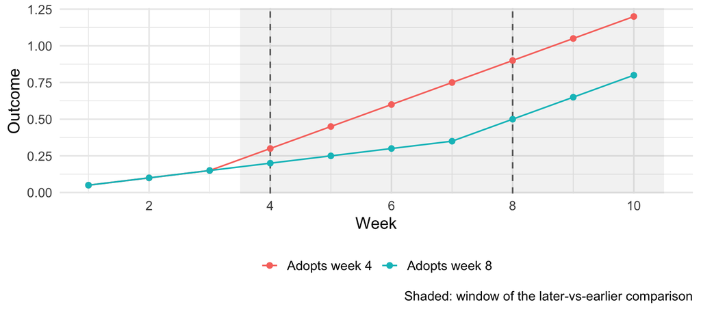

The toy panel has no noise, a common trend, and an effect that rises by 0.1 each week after adoption.

## The toy panel’s 2×2s

- True ATT: 0.340
- Earlier vs later (weeks 1–7): 0.250
- Later vs earlier (weeks 4–10): -0.150. The early cohort’s rising effect is subtracted.
- TWFE: 0.050, about 15% of the true ATT.

## Decomposing Case 05

| Comparison | Number of 2×2s | Total weight | Weighted mean 2×2 |
| --- | --- | --- | --- |
| Later vs earlier (already treated) | 3 | 0.181 | -0.102 |
| Earlier vs later | 3 | 0.181 | 0.189 |
| Treated vs never treated | 3 | 0.639 | 0.446 |

From `bacondecomp::bacon()`. Identity check: $\sum_j s_j \hat\beta_j =$ 0.3007; TWFE $\hat\beta =$ 0.3007.

## Every 2×2, by weight: Case 04 against Case 05

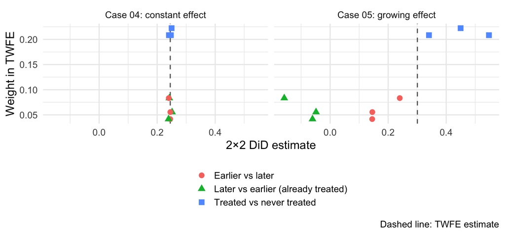

In Case 05 the later-vs-earlier comparisons turn negative: they subtract the early cohorts’ growing effects.

## Case 04 for contrast: same timing, constant effect

| Comparison | Number of 2×2s | Total weight | Weighted mean 2×2 |
| --- | --- | --- | --- |
| Later vs earlier (already treated) | 3 | 0.181 | 0.244 |
| Earlier vs later | 3 | 0.181 | 0.243 |
| Treated vs never treated | 3 | 0.639 | 0.246 |

The weights match Case 05’s. With a constant effect, every 2×2 recovers it.

## Case 05: choose the average

| Aggregation | Never-treated controls | Not-yet-treated controls |
| --- | --- | --- |
| Simple: all treated cells | 0.456 | 0.455 |
| By cohort, then averaged | 0.438 | 0.437 |
| By event time, then averaged | 0.540 | 0.539 |
| By calendar week, then averaged | 0.402 | 0.399 |

Each row answers a different question; pick the one that matches the estimand. Not-yet-treated controls add power but require no anticipation among later adopters.

# Case 06: spillovers

## Case 06: promotions spill over to nearby stores

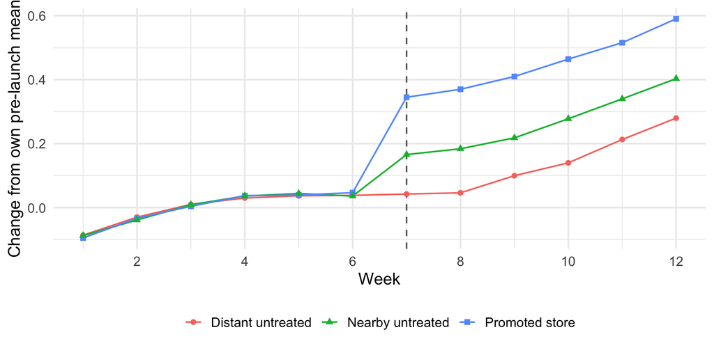

## Case 06: controls must be unexposed

| Specification | Estimate | Std. error | Planted ATT |
| --- | --- | --- | --- |
| All untreated stores as controls | 0.248 | 0.007 | 0.3 |
| Distant stores only | 0.312 | 0.006 | 0.3 |
| Nearby stores only | 0.184 | 0.005 | 0.3 |

Nearby stores gain from the promotion too, so using them as controls removes part of the effect. Define exposure before choosing controls.

# Case 07: effects that differ across stores

## Case 07: does app ordering work better in urban stores?

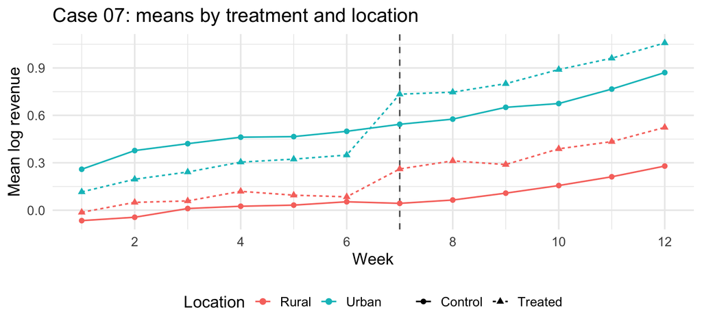

Urban stores adopt more often (56 of 80, against 24 of 80 rural stores) and grow faster whether or not they adopt.

## One DiD per location

Target: the ATT within each location $m$, and their difference.

$$\text{ATT}(m) = \mathbb{E}\big[\,Y_{it}(1) - Y_{it}(0) \mid \text{treated},\ \text{urban}_i = m,\ t \ge g\,\big]$$

Assumption: parallel trends **within each location** $m$, not across locations:

$$\mathbb{E}\big[\Delta Y_{it}(0) \mid \text{treated},\ \text{urban}_i = m\big] = \mathbb{E}\big[\Delta Y_{it}(0) \mid \text{control},\ \text{urban}_i = m\big]$$

Urban stores may trend differently from rural stores. Each location’s treated stores are compared only with that location’s controls.

| Location | Treated change | Control change | DiD |
| --- | --- | --- | --- |
| Rural | 0.302 | 0.142 | 0.160 |
| Urban | 0.610 | 0.266 | 0.344 |

Urban minus rural: 0.344 − 0.160 = 0.183. This is the triple difference.

## The same numbers from one regression

$$y_{it} = \alpha_i + \lambda_{t,\,\text{urban}_i} + \beta\, D_{it} + \gamma\, D_{it}\cdot\text{urban}_i + \varepsilon_{it}$$

```r
triple_fit_07 <- feols(
  outcome ~ treated + treated_urban | unit_id + period^urban,
  vcov = ~unit_id,
  data = d07
)
```

- `period^urban` gives each location its own week effects $\lambda_{t,\text{urban}}$: parallel trends are imposed within each location only.
- $\hat\beta =$ 0.160: the rural DiD. $\hat\beta + \hat\gamma =$ 0.344: the urban DiD.
- $\hat\gamma =$ 0.183 (SE 0.019): the difference between locations.

## Same as one regression per location

```r
location_fit_07 <- feols(outcome ~ i(urban, treated) | unit_id + period^urban,
                         vcov = ~unit_id, data = d07)
separate_fits_07 <- feols(outcome ~ treated | unit_id + period,
                          split = ~urban, vcov = ~unit_id, data = d07)
```

| Location | Separate: estimate | SE | Pooled: estimate | SE |
| --- | --- | --- | --- | --- |
| Rural | 0.1604 | 0.01320 | 0.1604 | 0.01316 |
| Urban | 0.3438 | 0.01374 | 0.3438 | 0.01370 |

- Each store belongs to one location, and each location has its own week effects, so the pooled model shares nothing across locations. It reproduces each location’s TWFE exactly, and $\hat\gamma$ is the difference of the two separate estimates.
- The standard errors differ only through fixest’s small-sample correction, which counts all stores in the pooled model.

## Case 07: leave out location-by-week effects

| Quantity | Location-by-week effects | SE | Common week effects | SE | Planted |
| --- | --- | --- | --- | --- | --- |
| Rural effect | 0.160 | 0.013 | 0.123 | 0.014 | 0.15 |
| Urban minus rural | 0.183 | 0.019 | 0.308 | 0.013 | 0.20 |
| ATT, all treated stores | 0.289 | 0.010 | 0.339 | 0.019 | 0.29 |

- With common week effects, the urban stores’ own trend is counted as treatment effect: the moderation coefficient compares urban with rural **treated** stores only.
- The last row pools both locations. Treated stores are mostly urban, so the pooled two-group TWFE inherits the urban trend too.

## Case 07: check pre-trends within each location

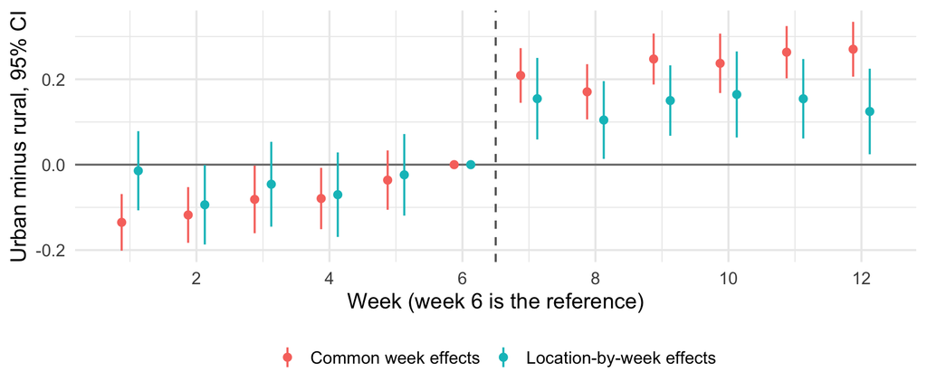

Joint test that the urban-minus-rural leads in weeks 1–5 are zero: p = 0.358 with location-by-week effects, p = 0.0002 with common week effects.

## Reading a moderated DiD

- $\gamma$ says the effect **differs** between urban and rural stores. It does not say that making a store urban would raise the effect: urban stores differ in many other ways.
- The moderator must be fixed before treatment and observed for control stores too. A moderator that treatment can change, or that exists only for treated stores, breaks the within-location comparison.
- Interaction terms need far more data than a main effect. A wide confidence interval on $\gamma$ is not evidence that the effect is the same everywhere.

# What pre-tests can and cannot show

## Pre-tests across the cases

| Case | Issue | Pre-test p | TWFE estimate | Planted ATT |
| --- | --- | --- | --- | --- |
| 01 | Clean benchmark | 0.855 | 0.302 | 0.30 |
| 02 | Composition differences | 0.000 | 0.372 | 0.25 |
| 03 | Pre-adoption dip | 0.000 | 0.104 | 0.00 |
| 06 | Spillovers | 0.706 | 0.248 | 0.30 |
| 08 | Bad control | 0.613 | 0.343 | 0.35 |

A rejection signals a problem, but a pass does not rule one out: spillovers (06) and bad controls (08) leave the pre-period untouched.

## Pre-tests have low power

| Added trend per week (treated) | Bias in TWFE | Pre-test p |
| --- | --- | --- |
| 0.000 | 0.00 | 0.855 |
| 0.005 | 0.03 | 0.450 |
| 0.010 | 0.06 | 0.100 |
| 0.015 | 0.09 | 0.009 |
| 0.020 | 0.12 | 0.000 |

Each row adds a linear trend to Case 01’s treated stores. A trend that passes the pre-test can still shift the estimate noticeably.

## After a pre-test

- Reporting only designs that pass a pre-test biases the published estimates (Roth 2022).
- Instead, bound how far the post-launch violation may exceed the pre-launch one and report how the estimate changes (Rambachan and Roth 2023, `HonestDiD`).

## Parallel trends depend on the outcome scale

Control stores go from 100 to 110. Treated stores start at 200.

| Assumption | Treated counterfactual |
| --- | --- |
| Parallel trends in **levels** | 210 (+5%) |
| Parallel trends in **logs** | 220 (+10%) |

Both can hold only if the groups start at the same level or nothing changes (Roth and Sant’Anna 2023).

In Case 01, pre-launch revenue is 1.22 (treated) and 1.23 (control), so the scale matters little there.

More on how the scale changes the estimand: didestimands.app.

# Optional: Case 08

## Case 08: advertising raises engagement

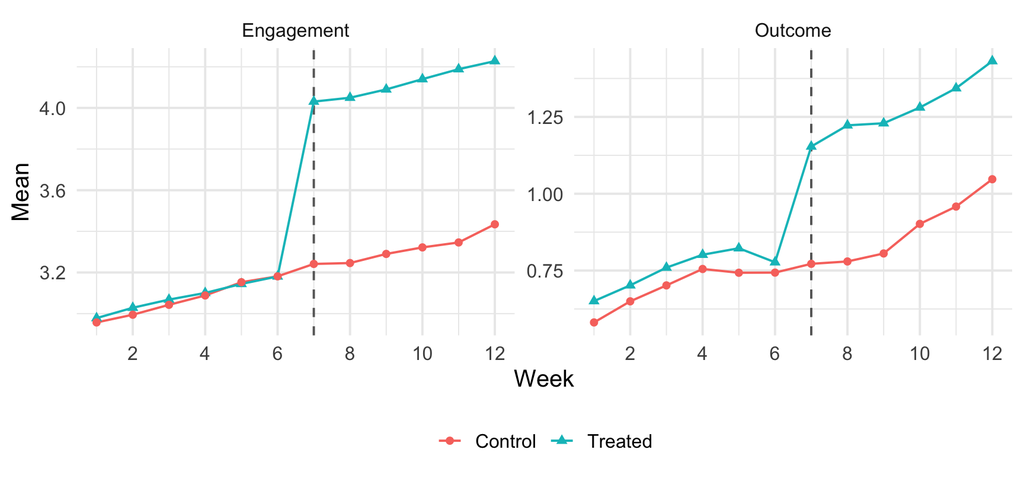

## Case 08: controlling for a mediator

| Specification | Estimate | Std. error | Planted ATT |
| --- | --- | --- | --- |
| TWFE without engagement | 0.343 | 0.011 | 0.35 |
| TWFE controlling for engagement | 0.170 | 0.031 | 0.35 |

Controlling for engagement removes the effect that runs through it, leaving the direct effect (planted 0.20). Use only covariates measured before treatment.

# Wrap-up

## What each case needed

[output not shown]

## Checklist before reporting a DiD

1. Plot treatment timing and group means.
2. State the estimand: which units, weeks, and average.
3. Defend the comparison group: parallel trends, no anticipation, no spillovers.
4. Adjust only for pre-treatment covariates; check overlap.
5. With staggered timing, use Callaway–Sant’Anna or Sun–Abraham.
6. Treat pre-tests as diagnostics; add a sensitivity analysis.
7. Cluster at the level of treatment assignment.

## References

- Arkhangelsky, D., Athey, S., Hirshberg, D. A., Imbens, G. W., & Wager, S. (2021). Synthetic difference-in-differences. *American Economic Review*, 111(12), 4088–4118.
- Callaway, B., & Sant’Anna, P. H. C. (2021). Difference-in-differences with multiple time periods. *Journal of Econometrics*, 225(2), 200–230.
- de Chaisemartin, C., & D’Haultfœuille, X. (2020). Two-way fixed effects estimators with heterogeneous treatment effects. *American Economic Review*, 110(9), 2964–2996.
- Goodman-Bacon, A. (2021). Difference-in-differences with variation in treatment timing. *Journal of Econometrics*, 225(2), 254–277.

## References (continued)

- Rambachan, A., & Roth, J. (2023). A more credible approach to parallel trends. *Review of Economic Studies*, 90(5), 2555–2591.
- Roth, J. (2022). Pretest with caution: Event-study estimates after testing for parallel trends. *American Economic Review: Insights*, 4(3), 305–322.
- Roth, J., & Sant’Anna, P. H. C. (2023). When is parallel trends sensitive to functional form? *Econometrica*, 91(2), 737–747.
- Sun, L., & Abraham, S. (2021). Estimating dynamic treatment effects in event studies with heterogeneous treatment effects. *Journal of Econometrics*, 225(2), 175–199.